# Vou te provar que da para fazer grafos bonitos em R!

Fellipe Gomes

11/28/2021

# Introdução e contexto

Durante os anos de 2020 e 2021 fiz um [MBA Executivo em Business Analytics e Big Data](https://educacao-executiva.fgv.br/df/brasilia/cursos/mba-pos-graduacao/mba-presencial/mba-executivo-em-business-analytics-e-big-data) na FGV e uma das disciplinas gostei bastante abordou a análise de mídias sociais com técnicas de mineração de texto e processamento de linguagem natural.

No trabalho final fomos desafiados a extrair dados da internet via api ou scraping, aplicar a metodologia apropriada para extrair informações de interesse e contruir um Grafo.

## O que são Grafos?

📎 Segundo o Wikipedia:

> “A teoria dos grafos é um ramo da matemática que estuda as relações entre os objetos de um determinado conjunto”

### Como contruir um?

Aprendemos a mexer no [Gephi](https://gephi.org/) para a contrução desses Grafos (ferramenta incrível, diga-se de passagem) porém ouvi diversas vezes, tanto dentro quanto fora da FGV, que R e Python eram muito limitados para construção de Grafos bonitos e que esse software sempre a melhor opção.

Apesar do enorme potencial do Gephi, fiquei um pouco entediado estudando-o pois não sou grande fã de ferramentas *point-and-click* e quando o professor falou que a escolha da ferramenta para a construção do Grafo era livre, resolvi tentar fazê-lo em R!

### Para que servem os grafos

Como esse gráfico deu mais de trabalho do que eu esperava e fiquei bem satisfeito com o resultado final, resolvi procurar outros dados e fazer uma nova análise para praticar e publicar aqui no blog, espero que gostem!

# Carregar dependencias

```r
library(rvest) # web scrapping
library(dplyr) # manipulate data
library(purrr) # functional prog
library(stringr) # str toolkit
library(spacyr) # ner
library(igraph) # base graph
library(tidygraph) # tidy graph
library(ggraph) # plot graph
```

```r
scrape_post_links <- function(site) {
  cat(paste0(site, "\n"))

  source_html <- read_html(site)

  links <- source_html %>%
    html_nodes("div.widget--info__text-container") %>%
    html_nodes("a") %>%
    html_attr("href")

  links <- links[!is.na(links)]

  return(links)
}

scrape_post_body <- function(site) {

  text <- tryCatch({
    cat(paste0(site, "\n"))
    body <- site %>%
      read_html %>%
      html_nodes("article") %>%
      html_nodes("p.content-text__container")  %>%
      html_text %>%
      paste(collapse = '')

  }, error = function(e){
    cat(paste("ERRO 404", "\n"))
    body <- NA
  })

  return(body)
}

get_adjacent_list <- function(edge_list) {
  gtools::combinations(length(edge_list), 2, edge_list)
}
```

# Fonte dos dados

Textos jornalisticos apresentam a vantagem de serem bem escritos

```r
# raiz
root <- "https://g1.globo.com/busca/?q=economia+brasil"

# link das proximas 100 paginas
all_pages <- c(root, paste0(root, "&page=", 1:50))

# coletar os links dos posts de cada pagina
all_links <- map(all_pages, scrape_post_links) %>% unlist()

# extrair urls
cleaned_links <- map_chr(all_links, ~{
  .x %>%
    urltools::param_get() %>%
    pull(u) %>%
    urltools::url_decode()
})

# reter apenas links que falam de economia
cleaned_links <- cleaned_links %>% .[str_detect(.,  "g1.globo.com/economia")]

# nao reter links do globoplay
cleaned_links <- cleaned_links %>% .[!str_detect(.,  "globoplay")]

# coletar conteudo de cada link
data <- map_chr(cleaned_links, scrape_post_body) %>% unique()
```

# NER - Named Entity Recognition

Configurar o `spacyr` para utilizar o modelo pré treinado para reconhecimento de entidades em portugues:

```r
spacyr::spacy_install()
spacy_download_langmodel("pt_core_news_sm")
```

```r
spacy_initialize(model="pt_core_news_sm")
```

```r
entities <- spacy_extract_entity(data)
entities
```

```r
filtered_entities <-
  entities %>%
  filter(ent_type=='ORG'|ent_type=='PER')

filtered_entities %>% count(text, sort = T) %>% head(50)
```

# Obter elementos do Grafo

```r
filtered_entities <- readRDS("filtered_entities.rds")
```

```r
# Criar lista de arestas (edges or links)
edges <-
  filtered_entities %>%
  group_by(doc_id) %>%
  summarise(entities = paste(text, collapse = ",")) %>%
  pull(entities) %>%
  str_split(",") %>%
  map(~unique(unlist(.x))) %>%
  .[map_dbl(., length) != 1]
```

```r
adjacent_matrix <-
  map_dfr(edges, ~
                   as.data.frame(get_adjacent_list(.x))) %>%
  as_tibble() %>%
  set_names(c('item1', 'item2'))
```

```r
adjacent_matrix <- adjacent_matrix %>%
  mutate_all(~.x %>%
               str_replace_all("Fundação Getulio Vargas", "FGV") %>%
               str_replace_all("FMI", "Fundo Monetário Internacional") %>%
               str_replace_all("Paulo Guedes", "Guedes") %>%
               str_replace_all("Estados Unidos( da Am[ée]rica)?", "EUA") %>%
               str_replace_all("Donald Trump", "Trump") %>%
               str_replace_all("CEF", "Caixa Econômica Federal") %>%
               str_replace_all("CMN", "Conselho Monetário Nacional") %>%
               str_replace_all("Cl[áa]udio Considera", "Cláudio") %>%
               str_replace_all("OCDE", "Organização para a Cooperação e\n Desenvolvimento Econômico") %>%
               str_replace_all("(André )?Brandão", "André Brandão") %>%
               str_replace_all("(Maur[ií]cio )?Macri", "Mauricio Macri") %>%
               str_remove_all("^(?i)(no|de)\\s")

             )

entities_to_drop <- c("Assine", "Google Podcasts", "Spotify", "Focus do",
                      "Focus", "Segundo", "Ninguém", "Haverá", "G1",
                      "Começa", "LEIA", "R$", "Considera", "Caixa Aqui")

weighted_edgelist <- adjacent_matrix %>%
  filter_at(1:2, ~ !.x %in% entities_to_drop) %>%
  group_by(item1, item2) %>%
  summarise(n=n()) %>%
  ungroup() %>%
  filter(n>3)
```

```r
a <- grid::arrow(type = "closed", length = unit(.15, "inches"))
subt <- weighted_edgelist
vert <- subt %>% tidyr::gather(item, word, item1, item2) %>%
  group_by(word) %>% summarise(n = sum(n))
```

```r
# Obter componentes para colorir os clusters do grafo
tidy_graph_components <-
  subt  %>%
  select(item1, item2) %>%
  as.matrix() %>%
  graph.edgelist(directed = FALSE)  %>%
  as_tbl_graph() %>%
  activate("edges") %>%
  mutate(weight = subt$n) %>%
  activate("nodes") %>%
  # ttps://tidygraph.data-imaginist.com/reference/group_graph.html # tipos de agrupamentos
  mutate(component = as.factor(tidygraph::group_edge_betweenness()))
# Atualizar vertice para incluir componentes
vert <- vert %>%
  left_join( as.data.frame(activate(tidy_graph_components, "nodes")) %>%
               rename(word = name))
```

```r
set.seed(1)
subt %>%
  graph_from_data_frame(vertices = vert) %>%
  # https://www.data-imaginist.com/2017/ggraph-introduction-layouts/ # layouts
  ggraph(layout = "fr") +
  geom_edge_link(aes(edge_alpha = n, edge_width = n), show.legend = FALSE,
                 arrow = a, end_cap = circle(.07, 'inches'), color = "#D9D9D9A0") +
  geom_node_point() +
  geom_node_text(aes(label = name, size = n, alpha = n, color = component),# color = "#EAFF00",
                 repel = TRUE, point.padding = unit(0.2, "lines"),
                 show.legend = F) +
  scale_size(range = c(2,10)) +
  scale_alpha(range = c(0.5,1))+
  theme_dark() +
  theme(
    panel.background = element_rect(fill = "#2D2D2D"),
    legend.key = element_rect(fill = "#2D2D2D")
  ) +
  theme_graph(background = "black")
```

```r
ggsave(filename = 'grafo.png', width = 8, height = 6, device='png', dpi=700)
```

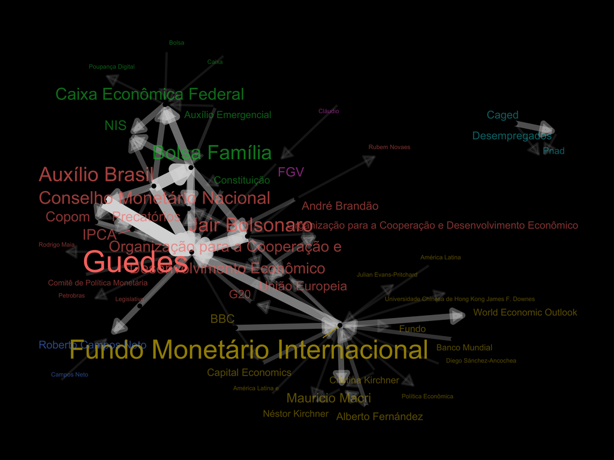

- Fundo Monetário Internacional

O FMI [trabalha para melhorar as economias dos países](https://pt.wikipedia.org/wiki/Fundo_Monet%C3%A1rio_Internacional) e além da Argentina estar endividada e em acordo com o FMI, está em época de eleição, o que explica haver alguns personagens de sua política relacionados.

- Guedes

Paulo Guedes é nosso atual ministro da economia e envolta de seu nome aparecem diversos assuntos que estão em pauta atualmente como a PEC dos precatórios, (a privatização da) Petrobrás, Copom, IPCA, Auxílio Brasil dentre outros.

- Bolsa familia

O Auxílio Brasil é referido como o “Novo Bolsa Família” pelos jornais e por isso deve ter sido criada tal relação no Grafo. Já a Caixa Econômica Federal é o agente que executa os pagamentos.